# QM - Programming Basics 6 - Functions cont’d, loops and conditionals

Functions

Functions are a way to do specific computing tasks (say finding mean) that you might want to do in a number of contexts.

They take input, return output based on a set of instructions or computations

All R math functions and other commands are actually just R function codes

Function format: FuncName = function(x) { Code for calculating y or whatever Return y }

In our daylight hours example, it would make sense to make a function of the daylight hrs calculation. That would allow us to use it in a variety of contexts.

```r
#calculates daylight hours for given latitude and yearday
daylighthrs = function(latitude,yearday) {

  latrad = latitude*pi/180 #degree  #-> radians
  solar_declination = 0.4093*sin((2*pi/365)*yearday-1.405) #solar declination
  sunset_hour_angle = acos(-tan(latrad)*tan(solar_declination)) #sunset hour angle
  daylight_hrs = 24*sunset_hour_angle/pi #hours in day
  return(daylight_hrs)
}
```

Try it out…

```r
x = daylighthrs(45,250)
print(x)
```

```
## [1] 12.75616
```

Can we input a vector of days?

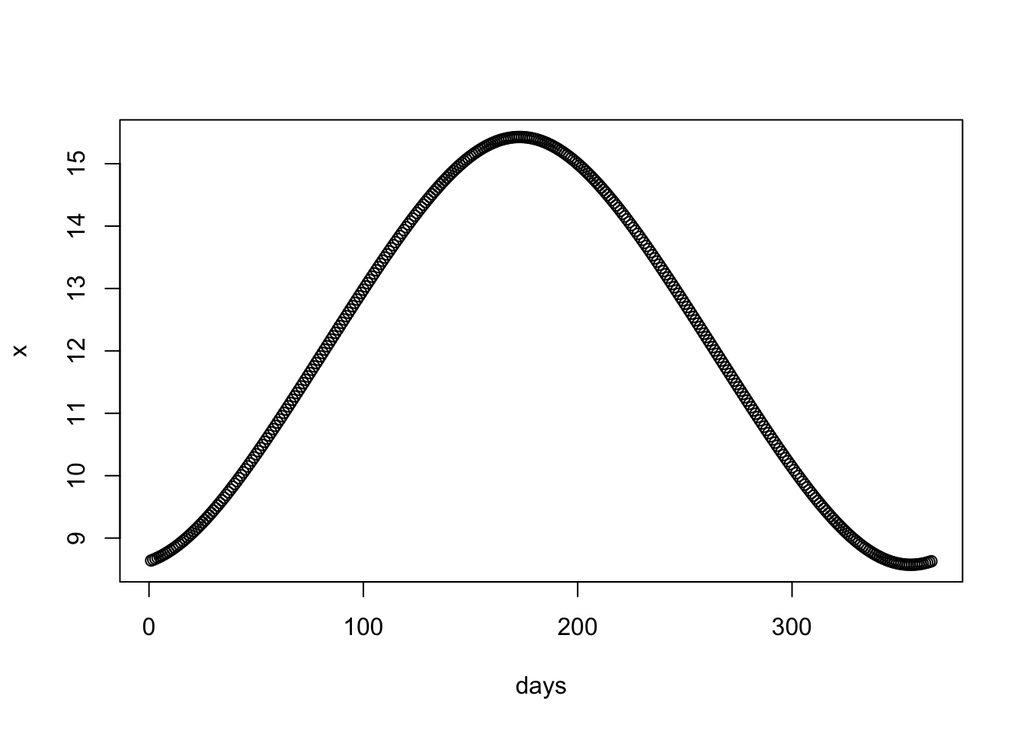

```r
days = 1:365
x = daylighthrs(45,days)
plot(days,x)
```

Yes!! also

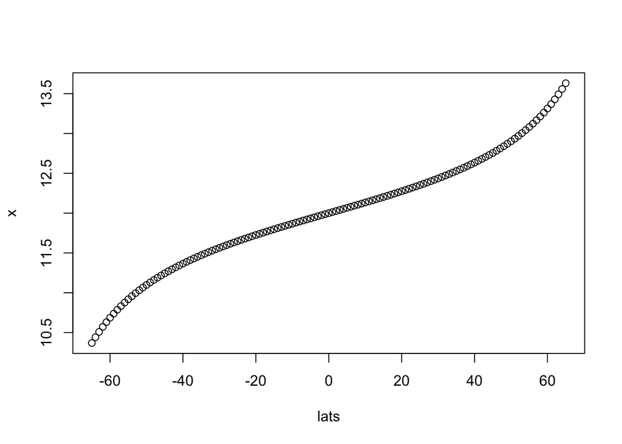

```r
lats = -65:65
day = 250
x = daylighthrs(lats,day)
plot(lats,x)
```

Now try

```r
lats = -65:65
days = 1:365
mx = daylighthrs(lats,days)
dim(mx)
```

[output not shown]

Calculated something, but not what we wanted.

**Loops**

Loops are useful programming structure for repeating a command until a certain condition is reached (certain number of times, until end of file, until a value is sufficiently small, …)

Say we wanted to multiply elements of 2 vectors x and y together. We could write:

x=1:10; y=11:20; nx=length(x) f = rep(0,nx) for (n in 1:nx) { f [n]= x[n] * y[n] }

Does it make sense to do this? NO! because we can just write f = x*y. Loops are less efficient and more space consuming than using vector operations. But sometimes they are necessary or clearer than avoiding them.

Let’s extend our daylight hour calculation to loop over latitude.

```r
dhmatrix = matrix(NA,365,131)  #fills with NA
lats = -65:65
days = 1:365
for (i in 1:length(lats)){
  dhi = daylighthrs(lats[i],days)
  dhmatrix[,i]=dhi
}
dim(dhmatrix)
```

```
## [1] 365 131
```

```r
dhmatrix[1:5,1:5]
```

```
##          [,1]     [,2]     [,3]     [,4]     [,5]
## [1,] 20.78828 20.10503 19.55554 19.09202 18.68978
## [2,] 20.72527 20.05449 19.51250 19.05416 18.65579
## [3,] 20.65803 20.00020 19.46612 19.01327 18.61903
## [4,] 20.58682 19.94232 19.41650 18.96945 18.57957
## [5,] 20.51191 19.88102 19.36377 18.92277 18.53748
```

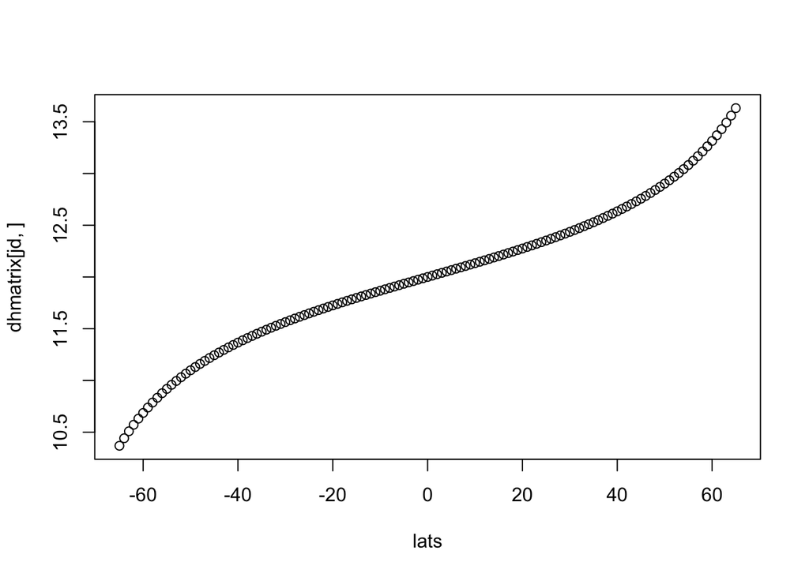

```r
jd = which(days == 250)
jl = which(lats == 45)
plot(lats,dhmatrix[jd,])
```

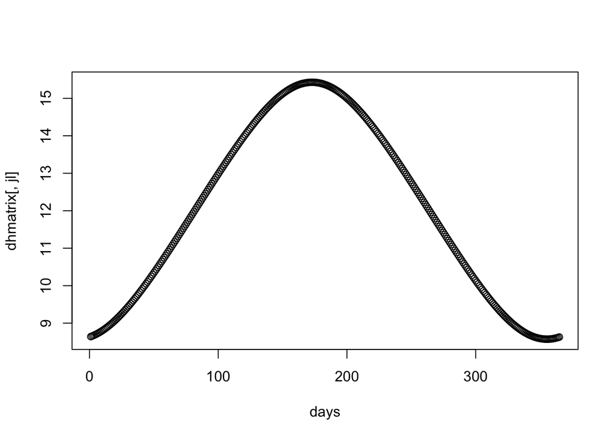

```r
plot(days,dhmatrix[,jl])
```

**Conditionals (if-then-else statements)**

If statements: If test is T, statement is executed. If F, nothing happens. E.g., smeone asked on Monday what happens if someone entered an incorrect value into the daylighthrs code or function. Say day=1000 or lat = 100 (or even 70)?

```r
lats = 45
days = -10
dhi = daylighthrs(lats,days)
print(dhi)
```

```
## [1] 8.572228
```

It gives an answer but it doesn’t make sense that it would.

```r
lats = 100
days = 250
dhi = daylighthrs(lats,days)
print(dhi)
```

```
## [1] 7.455202
```

Same here! It is good practice to check whether input values conform to limits for the values. We can do this with an if-then type construction.

```r
#calculates daylight hours for given latitude and yearday
daylighthrs = function(latitude,yearday) {

  #check input values
  if (latitude > 65 | latitude < -65) {
    print("Value of latitude is out of bounds. Use a value between -65 and 65")
    break
  }
  if (days > 366 | days < 0) {
    print("Value of days is out of bounds. Use a value between 0-365")
    break
  }

  latrad = latitude*pi/180 #degree  #-> radians
  solar_declination = 0.4093*sin((2*pi/365)*yearday-1.405) #solar declination
  sunset_hour_angle = acos(-tan(latrad)*tan(solar_declination)) #sunset hour angle
  daylight_hrs = 24*sunset_hour_angle/pi #hours in day
  return(daylight_hrs)
}
```

```r
lats = 45
days = -10
#dhi = daylighthrs(lats,days)
#print(dhi)
```

```r
lats = 100
days = 250
#dhi = daylighthrs(lats,days)
#print(dhi)
```

There are many ways to use conditional statements. Let’s look at a simple example.

```r
for (n in 1:100) {
  print (n)
  if (n > 19) break
}
```

```
## [1] 1
## [1] 2
## [1] 3
## [1] 4
## [1] 5
## [1] 6
## [1] 7
## [1] 8
## [1] 9
## [1] 10
## [1] 11
## [1] 12
## [1] 13
## [1] 14
## [1] 15
## [1] 16
## [1] 17
## [1] 18
## [1] 19
## [1] 20
```

Result? Count from 1 to 20. When n=20, it is > 19 and loop breaks

If else: else only evaluated if test is F

```r
for (n in 1:40) {
  if (n <=19) {print (n)}
  else (print(n/2))
}
```

```
## [1] 1
## [1] 2
## [1] 3
## [1] 4
## [1] 5
## [1] 6
## [1] 7
## [1] 8
## [1] 9
## [1] 10
## [1] 11
## [1] 12
## [1] 13
## [1] 14
## [1] 15
```

[output cut: 25 more lines]

Some logical operators that can be used in tests: a. x == y tests for equality, b. <= or >= c. && or || Boolean and/or (for scalars) d. ! Boolean negation

e.g.:

```r
x = -5
if (x>0) print(x)
if (x<0) print(x*2)
```

```
## [1] -10
```

```r
x=-1
if (x<0 && x> -3) {
  print(x)
  } else {
  print("value not between -3 and 0")}
```

```
## [1] -1
```